# Data Exploration

## Initializing Libraries

```python
import pandas as pd
import matplotlib.pyplot as plt
from matplotlib import style
plt.style.use("seaborn-dark")
```

## Importing Data

```python
df = pd.read_csv('coding_round_data.csv')
```

## Data Exploration

```python
df.info()
```

```
<class 'pandas.core.frame.DataFrame'>
RangeIndex: 12330 entries, 0 to 12329
Data columns (total 18 columns):
 #   Column                   Non-Null Count  Dtype
---  ------                   --------------  -----
 0   Administrative           12330 non-null  int64
 1   Administrative_Duration  12330 non-null  float64
 2   Informational            12330 non-null  int64
 3   Informational_Duration   12330 non-null  float64
 4   ProductRelated           12330 non-null  int64
 5   ProductRelated_Duration  12330 non-null  float64
 6   BounceRates              12330 non-null  float64
 7   ExitRates                12330 non-null  float64
 8   PageValues               12330 non-null  float64
 9   SpecialDay               12330 non-null  float64
 10  Month                    12330 non-null  object
 11  OperatingSystems         12330 non-null  int64
 12  Browser                  12330 non-null  int64
 13  Region                   12330 non-null  int64
 14  TrafficType              12330 non-null  int64
 15  VisitorType              12330 non-null  object
 16  Weekend                  12330 non-null  bool
 17  Revenue                  12330 non-null  bool
dtypes: bool(2), float64(7), int64(7), object(2)
memory usage: 1.5+ MB
```

```python
df.head()
```

|  | Administrative | Administrative_Duration | Informational | Informational_Duration | ProductRelated | ProductRelated_Duration | BounceRates | ExitRates | PageValues | SpecialDay | Month | OperatingSystems | Browser | Region | TrafficType | VisitorType | Weekend | Revenue |
| --- | --- | --- | --- | --- | --- | --- | --- | --- | --- | --- | --- | --- | --- | --- | --- | --- | --- | --- |
| 0 | 0 | 0.0 | 0 | 0.0 | 1 | 0.000000 | 0.20 | 0.20 | 0.0 | 0.0 | Feb | 1 | 1 | 1 | 1 | Returning_Visitor | False | False |
| 1 | 0 | 0.0 | 0 | 0.0 | 2 | 64.000000 | 0.00 | 0.10 | 0.0 | 0.0 | Feb | 2 | 2 | 1 | 2 | Returning_Visitor | False | False |
| 2 | 0 | 0.0 | 0 | 0.0 | 1 | 0.000000 | 0.20 | 0.20 | 0.0 | 0.0 | Feb | 4 | 1 | 9 | 3 | Returning_Visitor | False | False |
| 3 | 0 | 0.0 | 0 | 0.0 | 2 | 2.666667 | 0.05 | 0.14 | 0.0 | 0.0 | Feb | 3 | 2 | 2 | 4 | Returning_Visitor | False | False |
| 4 | 0 | 0.0 | 0 | 0.0 | 10 | 627.500000 | 0.02 | 0.05 | 0.0 | 0.0 | Feb | 3 | 3 | 1 | 4 | Returning_Visitor | True | False |

*Administrative, Administrative Duration, Informational, Informational Duration, Product Related* and *Product Related Duration*: These represent the number of different types of pages visited by the visitor in that session and total time spent in each of these page categories. The values of these features are derived from the URL information of the pages visited by the user and updated in real time when a user takes an action, e.g. moving from one page to another.

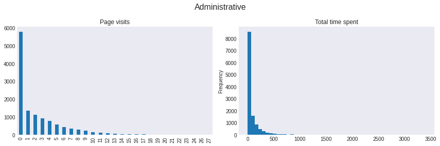

```python
fig, axes = plt.subplots(ncols=2, figsize=(12,4))
fig.suptitle("Administrative", fontsize=16)

df.Administrative.value_counts().sort_index().plot(kind='bar', ax=axes[0], title='Page visits')
df.Administrative_Duration.plot(kind='hist', ax=axes[1], title='Total time spent', bins=50)

fig.tight_layout()
```

```python
df[['Administrative', 'Administrative_Duration']].describe()
```

|  | Administrative | Administrative_Duration |
| --- | --- | --- |
| count | 12330.000000 | 12330.000000 |
| mean | 2.315166 | 80.818611 |
| std | 3.321784 | 176.779107 |
| min | 0.000000 | 0.000000 |
| 25% | 0.000000 | 0.000000 |
| 50% | 1.000000 | 7.500000 |
| 75% | 4.000000 | 93.256250 |
| max | 27.000000 | 3398.750000 |

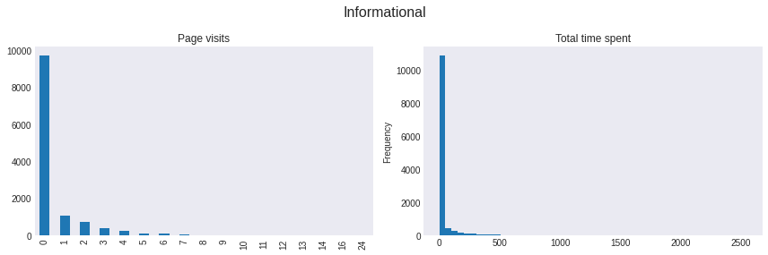

```python
fig, axes = plt.subplots(ncols=2, figsize=(12,4))
fig.suptitle("Informational", fontsize=16)

df.Informational.value_counts().sort_index().plot(kind='bar', ax=axes[0], title='Page visits')
df.Informational_Duration.plot(kind='hist', ax=axes[1], title='Total time spent', bins=50)

fig.tight_layout()
```

```python
df[['Informational', 'Informational_Duration']].describe()
```

|  | Informational | Informational_Duration |
| --- | --- | --- |
| count | 12330.000000 | 12330.000000 |
| mean | 0.503569 | 34.472398 |
| std | 1.270156 | 140.749294 |
| min | 0.000000 | 0.000000 |
| 25% | 0.000000 | 0.000000 |
| 50% | 0.000000 | 0.000000 |
| 75% | 0.000000 | 0.000000 |
| max | 24.000000 | 2549.375000 |

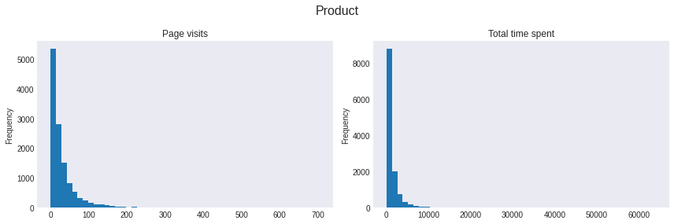

```python
fig, axes = plt.subplots(ncols=2, figsize=(12,4))
fig.suptitle("Product", fontsize=16)

df.ProductRelated.plot(kind='hist', ax=axes[0], title='Page visits', bins=50)
df.ProductRelated_Duration.plot(kind='hist', ax=axes[1], title='Total time spent', bins=50)

fig.tight_layout()
```

```python
df[['ProductRelated', 'ProductRelated_Duration']].describe()
```

|  | ProductRelated | ProductRelated_Duration |
| --- | --- | --- |
| count | 12330.000000 | 12330.000000 |
| mean | 31.731468 | 1194.746220 |
| std | 44.475503 | 1913.669288 |
| min | 0.000000 | 0.000000 |
| 25% | 7.000000 | 184.137500 |
| 50% | 18.000000 | 598.936905 |
| 75% | 38.000000 | 1464.157214 |
| max | 705.000000 | 63973.522230 |

*BounceRates*: Bounce rate value from GA

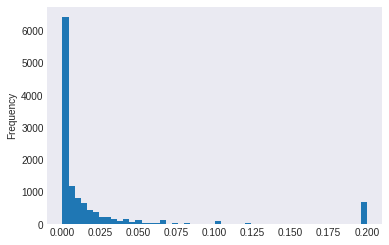

```python
df.BounceRates.plot(kind='hist', bins=50)
```

```python
df.BounceRates.describe()
```

```
count    12330.000000
mean         0.022191
std          0.048488
min          0.000000
25%          0.000000
50%          0.003112
75%          0.016813
max          0.200000
Name: BounceRates, dtype: float64
```

*ExitRates*: Exit rate value from GA

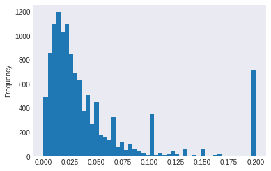

```python
df.ExitRates.plot(kind='hist', bins=50)
```

```python
df.ExitRates.describe()
```

```
count    12330.000000
mean         0.043073
std          0.048597
min          0.000000
25%          0.014286
50%          0.025156
75%          0.050000
max          0.200000
Name: ExitRates, dtype: float64
```

*PageValues*: Page value from GA

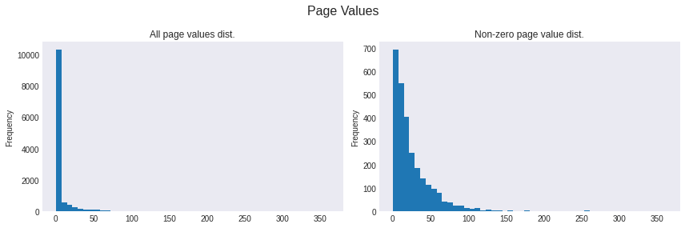

```python
fig, axes = plt.subplots(ncols=2, figsize=(12,4))
fig.suptitle("Page Values", fontsize=16)

df.PageValues.plot(kind='hist', ax=axes[0], title='All page values dist.', bins=50)
df.loc[df.PageValues > 0, "PageValues"].plot(kind='hist', ax=axes[1], title='Non-zero page value dist.', bins=50)

fig.tight_layout()
```

```python
df.PageValues.describe()
```

```
count    12330.000000
mean         5.889258
std         18.568437
min          0.000000
25%          0.000000
50%          0.000000
75%          0.000000
max        361.763742
Name: PageValues, dtype: float64
```

*SpecialDay, Month,* and *Weekend* are factors which can help describe temporal effects in shopping

*SpecialDay*: Feature indicating the proximity of a transaction to a day which boosts sales such as a festival

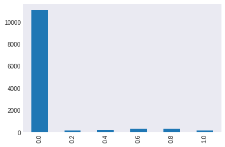

```python
df.SpecialDay.value_counts().sort_index().plot(kind='bar')
```

```python
df.SpecialDay.value_counts().sort_index()
```

```
0.0    11079
0.2      178
0.4      243
0.6      351
0.8      325
1.0      154
Name: SpecialDay, dtype: int64
```

Looking at non-zero values in-depth

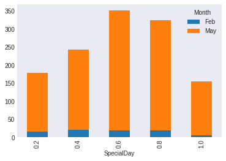

```python
temp = df.groupby('Month').SpecialDay.value_counts().unstack().T
temp = temp.iloc[1:6]
temp = temp.dropna(axis=1)
temp.plot(kind='bar',stacked=True)
```

It seems like the data is not for an entire year as a lot of SpecialDays such as Black Friday and Christmas are not showing up

```python
df.Month.unique()
```

```
array(['Feb', 'Mar', 'May', 'Oct', 'June', 'Jul', 'Aug', 'Nov', 'Sep',
       'Dec'], dtype=object)
```

Looking at the months, we can see that some months are missing all together

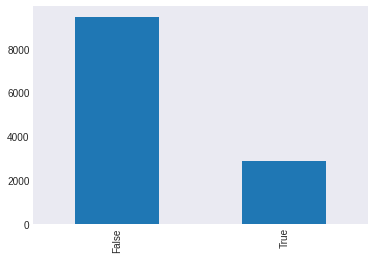

```python
df.Weekend.value_counts().plot(kind='bar')
```

*OperatingSystems , Browser, Region, TrafficType,* and *VisitorType* provide some information on the visitor. They are all categorical variables

```python
df.OperatingSystems.nunique()
```

```
8
```

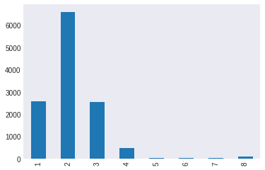

```python
df.OperatingSystems.value_counts().sort_index().plot(kind='bar')
```

```python
df.Browser.nunique()
```

```
13
```

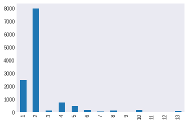

```python
df.Browser.value_counts().sort_index().plot(kind='bar')
```

```python
df.Region.nunique()
```

```
9
```

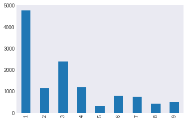

```python
df.Region.value_counts().sort_index().plot(kind='bar')
```

```python
df.TrafficType.nunique()
```

```
20
```

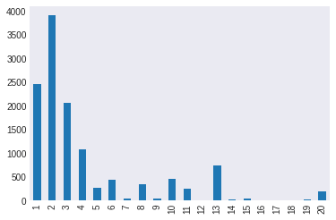

```python
df.TrafficType.value_counts().sort_index().plot(kind='bar')
```

```python
df.VisitorType.unique()
```

```
array(['Returning_Visitor', 'New_Visitor', 'Other'], dtype=object)
```

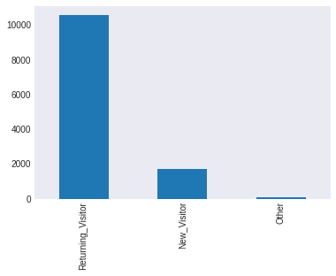

```python
df.VisitorType.value_counts().plot(kind='bar')
```

*Revenue*: Whether the customers made a purchase or not

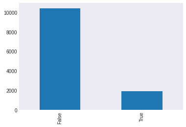

```python
df.Revenue.value_counts().plot(kind='bar')
```